# Example 1 (fallback) — GC content around TSS, without BSgenome

## Downloading the genome FASTA files

This version **does not need BSgenome packages** (~1.4 GB of R packages). Instead, it reads the genome from gzipped Ensembl FASTA files downloaded once:

- Human (GRCh38): ~1.0 GB
- Zebrafish (GRCz11): ~0.5 GB

From the terminal, at the repository root:

```bash
cd data/seq_data
bash get_data.sh
```

Or directly from R:

```r
dir.create("data/seq_data", recursive = TRUE, showWarnings = FALSE)
download.file(
  "https://ftp.ensembl.org/pub/release-113/fasta/homo_sapiens/dna/Homo_sapiens.GRCh38.dna_sm.toplevel.fa.gz",
  "data/seq_data/Homo_sapiens.GRCh38.dna_sm.toplevel.fa.gz")
download.file(
  "https://ftp.ensembl.org/pub/release-113/fasta/danio_rerio/dna/Danio_rerio.GRCz11.dna_sm.toplevel.fa.gz",
  "data/seq_data/Danio_rerio.GRCz11.dna_sm.toplevel.fa.gz")
```

## Load libraries

```r
library(Biostrings)
library(BSgenome)      # for getSeq(); no species package needed
library(rtracklayer)
library(ggplot2)
```

No BSgenome species package needed — `getSeq()` also works on a plain `DNAStringSet` if the sequences are named.

## The biological question

- Protein-coding genes in vertebrates are typically embedded in **GC-rich regions**, with the peak right at the transcription start site (TSS).
- That GC peak overlaps with **CpG islands** and correlates with:
  - open chromatin,
  - efficient mRNA nuclear export,
  - higher translation efficiency.
- Plan for this example:
  1. Extract ±1 kb windows around TSSs in **human** and **zebrafish**.
  2. Compute GC content in a 50 bp sliding window.
  3. Average across thousands of TSSs.
  4. Compare against the whole-genome GC baseline.

## Loading genomes from FASTA

`readDNAStringSet()` reads the whole (gzipped) FASTA file into a named `DNAStringSet` — one sequence per chromosome / contig / scaffold.

Unlike BSgenome, nothing is loaded lazily — the full genome is parsed into memory. For human that’s roughly 3 GB of decompressed sequence.

```r
hsapiens_genome_path <- "data/seq_data/Homo_sapiens.GRCh38.dna_sm.toplevel.fa.gz"
drerio_genome_path   <- "data/seq_data/Danio_rerio.GRCz11.dna_sm.toplevel.fa.gz"

hs_genome     <- readDNAStringSet(hsapiens_genome_path)
drerio_genome <- readDNAStringSet(drerio_genome_path)
```

```r
hs_genome
```

```
DNAStringSet object of length 706:
          width seq                                         names
  [1] 248956422 NNNNNNNNNNNNNNNNNNNN...NNNNNNNNNNNNNNNNNNNN 1
  [2] 242193529 NNNNNNNNNNNNNNNNNNNN...NNNNNNNNNNNNNNNNNNNN 2
  [3] 198295559 NNNNNNNNNNNNNNNNNNNN...NNNNNNNNNNNNNNNNNNNN 3
  [4] 190214555 NNNNNNNNNNNNNNNNNNNN...NNNNNNNNNNNNNNNNNNNN 4
  [5] 181538259 NNNNNNNNNNNNNNNNNNNN...NNNNNNNNNNNNNNNNNNNN 5
  ...       ... ...
[702]       993 GCCCCACGTCCGGGAGGGAG...GGAGGTGGGGGGTCAGCCCT KI270539.1
[703]       990 TTTCATAGAGCATGTTTGAA...GAAACTTGTTGTGATGTGTG KI270385.1
[704]       981 AGATTTCGTTGGAACGGGAT...GCTTTCAAACACTCTTTTTG KI270423.1
[705]       971 ATTTGCGATGTGTGTTCTCA...GATAGCTTTGAAGTTTTCGT KI270392.1
[706]       970 AAGTGGATATTTGGATAGCT...TCAATAACAGAGTTGAACCT KI270394.1
```

## Cleaning FASTA header names

Ensembl FASTA headers carry extra metadata after the chromosome name:

```r
# headers before cleaning
head(names(readDNAStringSet("../../data/seq_data/Homo_sapiens.GRCh38.dna_sm.toplevel.fa.gz",
                            nrec = 3)), 3)
```

```
[1] "1 dna_sm:chromosome chromosome:GRCh38:1:1:248956422:1 REF"
[2] "2 dna_sm:chromosome chromosome:GRCh38:2:1:242193529:1 REF"
[3] "3 dna_sm:chromosome chromosome:GRCh38:3:1:198295559:1 REF"
```

`getSeq()` requires an exact match between the BED seqnames and the FASTA names — keep just the first word (everything before the first space):

```r
names(hs_genome)     <- gsub(" .*", "", names(hs_genome))
names(drerio_genome) <- gsub(" .*", "", names(drerio_genome))
```

```r
head(names(hs_genome), 5)
```

```
[1] "1" "2" "3" "4" "5"
```

## Importing BED files with rtracklayer

The TSS coordinates were pre-computed and saved as BED. Each row is a ±1 kb window centered on a TSS → width = 2001 bp.

```r
hsapiens_bed_path <- "../../data/seq_data/tss_hs.bed"
drerio_bed_path   <- "../../data/seq_data/tss_drerio.bed"

hs_bed     <- import(hsapiens_bed_path, format = "BED")
drerio_bed <- import(drerio_bed_path,   format = "BED")

length(hs_bed)
```

```
[1] 320877
```

```r
width(hs_bed)[1:5]
```

```
[1] 2001 2001 2001 2001 2001
```

```r
hs_bed
```

```
GRanges object with 320877 ranges and 2 metadata columns:
           seqnames        ranges strand |        name     score
              <Rle>     <IRanges>  <Rle> | <character> <numeric>
       [1]        Y 385907-387907      - |        <NA>         0
       [2]        Y 340711-342711      - |        <NA>         0
       [3]        Y 346324-348324      - |        <NA>         0
       [4]        Y 344629-346629      - |        <NA>         0
       [5]        Y 344626-346626      - |        <NA>         0
       ...      ...           ...    ... .         ...       ...
  [320873]        1 180200-182200      - |        <NA>         0
  [320874]        1 119932-121932      - |        <NA>         0
  [320875]        1 128217-130217      - |        <NA>         0
  [320876]        1 128173-130173      - |        <NA>         0
  [320877]        1 132566-134566      - |        <NA>         0
  -------
  seqinfo: 24 sequences from an unspecified genome; no seqlengths
```

## Seqname conventions match here

In Example 2 (BSgenome) we had to prepend `"chr"` because UCSC uses `"chr1"`, `"chr2"`, … while the BED file uses Ensembl-style `"1"`, `"2"`, …

With Ensembl FASTA we are already in the Ensembl world — **no rename needed**.

```r
seqlevels(hs_bed) |> head()
```

```
[1] "Y"  "13" "21" "18" "20" "22"
```

```r
names(hs_genome)  |> head()
```

```
[1] "1" "2" "3" "4" "5" "6"
```

```r
all(seqlevels(hs_bed) %in% names(hs_genome))
```

```
[1] TRUE
```

## Extracting sequences with `getSeq()`

`getSeq()` works on a plain `DNAStringSet` too — the set just needs named sequences, and the BED seqlevels must match those names. Strand is respected: minus-strand ranges are **reverse-complemented** automatically.

```r
hs_sequences     <- getSeq(hs_genome,     hs_bed)
drerio_sequences <- getSeq(drerio_genome, drerio_bed)

hs_sequences
```

```
DNAStringSet object of length 320877:
         width seq
     [1]  2001 TTACTTATTGAGTCTGGCTCGATTTATGCAG...GGCTGATGTTGTATTTTTAGTAGAGACTGGG
     [2]  2001 GGTCTCACTCCCGCCTCCCGTTGGCGAGGTC...CCAGGGTGAGGGGACGGACGGGCGAGAGGAC
     [3]  2001 GGATTACAGGCATGAGCCACCACGCCCAGCC...CAAGGGCGCGCCCCTCTCCCGGCTCCCGGTC
     [4]  2001 CTTCTGCGGACGGGGCGGGCGGGGCCCGGGG...AGCGCCGGCCCGTGTGGCCTGGGCCAGCACC
     [5]  2001 CTGCGGACGGGGCGGGCGGGGCCCGGGGTTC...GCCGGCCCGTGTGGCCTGGGCCAGCACCTGC
     ...   ... ...
[320873]  2001 AGGGCTTCACCTGTTAGACTGGCAAAAATCC...AGGGTAAGGATTAGGGTTAGGATTAGGGTAA
[320874]  2001 GCTTTGTACTGGGAGGAGGGCGTGAAGGGCT...AATTCAATACATGCCTACTGATATGGTTAGG
[320875]  2001 AACCTCCGCTTCCTGGGTTCAAGCGATTCTC...TAGTTTTTATGATAAAAGGTTGGATTTTGAT
[320876]  2001 CCAAGTAGCTGGGACTACAGGTGTGTGCCAC...ATTTTGTGTCAGAATTAAAACTGGTATTAGA
[320877]  2001 CGCCTCCCTGTGGCCCAAGGCCCTCTTCACA...AGGTGGATCGGGGGACCCTGGGGGCTCAGGA
```

## `letterFrequencyInSlidingView()`

For a single sequence and a window of width `W`:

- slides a window of width `W` across the sequence,
- returns, for each window position, the count of the requested letters.

Output is a matrix with `length(seq) − W + 1` rows, one column per letter set.

```r
n <- 5000
x <- sapply(sample(hs_sequences, n), function(seq) {
  letterFrequencyInSlidingView(seq, view.width = 50, letters = "GC")
})
dim(x)   # rows = window positions, cols = sampled TSSs
```

```
[1] 1952 5000
```

## Average GC profile around human TSS

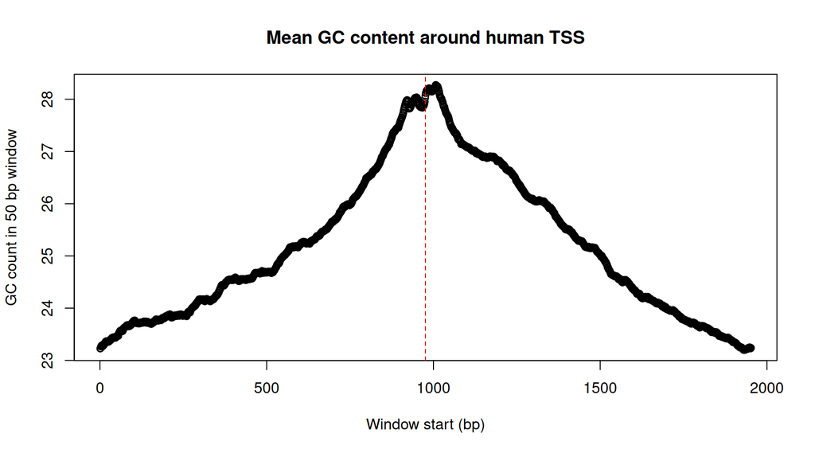

```r
gc_mean_content <- rowMeans(x, na.rm = TRUE)
plot(gc_mean_content,
     xlab = "Window start (bp)",
     ylab = "GC count in 50 bp window",
     main = "Mean GC content around human TSS")
n_windows <- length(gc_mean_content)
abline(v = n_windows / 2, col = "red", lty = 2)
```

The peak sits right at the TSS — exactly where we expected.

## A reusable profile function

The same logic works for any letter set (GC, AT, CG, single bases) and any window width. Wrap it up once, reuse it everywhere.

```r
get_N_profile <- function(s, W = 50, letters = "GC", sample_size = 5000) {
  x <- sapply(sample(s, sample_size), function(seq) {
    letterFrequencyInSlidingView(seq, view.width = W, letters = letters)
  })
  mean_content <- rowMeans(x, na.rm = TRUE)
  mean_content / W          # normalise to a per-base proportion in [0, 1]
}

hs_gc_profile <- get_N_profile(hs_sequences,     W = 50, letters = "GC")
dr_gc_profile <- get_N_profile(drerio_sequences, W = 50, letters = "GC")
```

> 📝 **Task 1** — compute separate A, T, G, and C profiles for the human set and overlay them. Which bases drive the peak at the TSS?

## Comparing species with base R

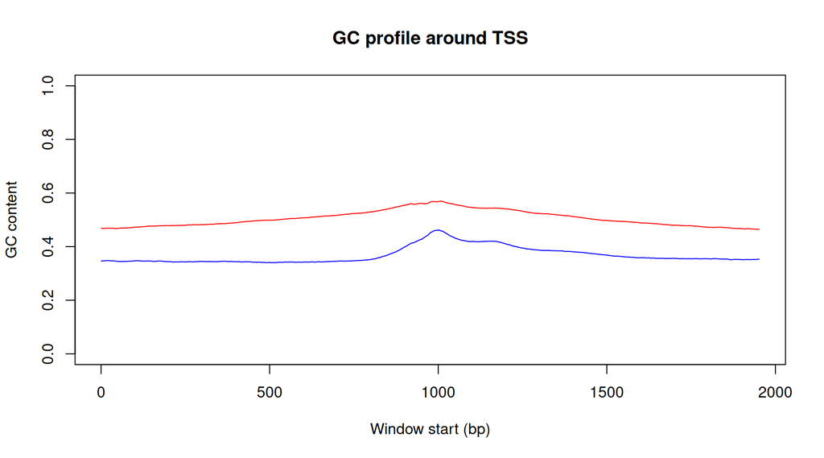

```r
plot(dr_gc_profile, type = "l", col = "blue", ylim = c(0, 1),
     xlab = "Window start (bp)", ylab = "GC content",
     main = "GC profile around TSS")
points(hs_gc_profile, type = "l", col = "red")
```

## Genome-wide GC baseline

Is the TSS peak really unusual? We need a reference. Without BSgenome we compute it across **all** sequences in the `DNAStringSet` using `alphabetFrequency()` plus `colSums()`.

```r
hs_content       <- alphabetFrequency(hs_genome)
hs_content_total <- colSums(hs_content) / sum(hs_content)

dr_content       <- alphabetFrequency(drerio_genome)
dr_content_total <- colSums(dr_content) / sum(dr_content)

gc_hs_genome <- sum(hs_content_total[c("C", "G")])
gc_dr_genome <- sum(dr_content_total[c("C", "G")])

cat("Human   genome GC:", round(gc_hs_genome, 3), "\n")
```

```
Human   genome GC: 0.39
```

```r
cat("Zebrafish genome GC:", round(gc_dr_genome, 3), "\n")
```

```
Zebrafish genome GC: 0.365
```

Both TSS peaks sit well above each species’ own genome-wide baseline.

## Baselines on the plot

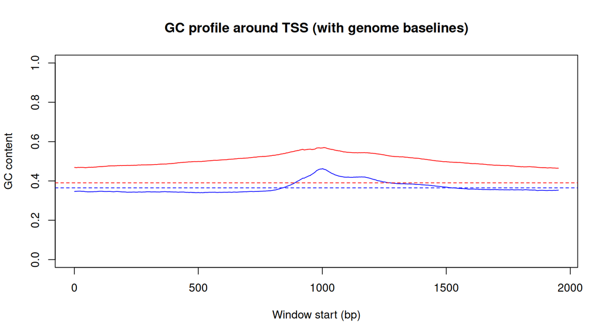

```r
plot(dr_gc_profile, type = "l", col = "blue", ylim = c(0, 1),
     xlab = "Window start (bp)", ylab = "GC content",
     main = "GC profile around TSS (with genome baselines)")
points(hs_gc_profile, type = "l", col = "red")
abline(h = gc_hs_genome, col = "red",  lty = 2)
abline(h = gc_dr_genome, col = "blue", lty = 2)
```

## The same figure with ggplot2

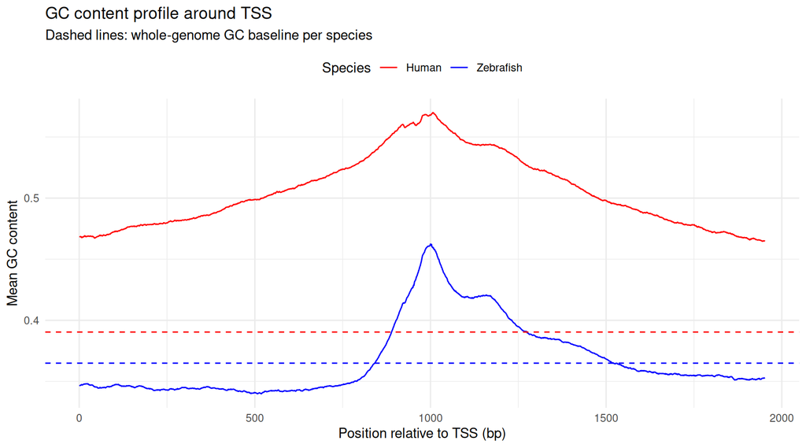

```r
gc_profile_df <- data.frame(
  Position   = 1:length(hs_gc_profile),
  GC_Content = c(hs_gc_profile, dr_gc_profile),
  Species    = rep(c("Human", "Zebrafish"), each = length(hs_gc_profile))
)

ggplot(gc_profile_df, aes(x = Position, y = GC_Content, color = Species)) +
  geom_line() +
  scale_color_manual(values = c("Human" = "red", "Zebrafish" = "blue")) +
  geom_hline(yintercept = gc_hs_genome, color = "red",  linetype = "dashed") +
  geom_hline(yintercept = gc_dr_genome, color = "blue", linetype = "dashed") +
  labs(title = "GC content profile around TSS",
       subtitle = "Dashed lines: whole-genome GC baseline per species",
       x = "Position relative to TSS (bp)",
       y = "Mean GC content") +
  theme_minimal() +
  theme(legend.position = "top")
```

> 📝 **Task 2** — rescale the x-axis so the TSS sits at 0 and the axis runs from roughly -1000 to +1000 bp.

## Summary — and trade-off vs. BSgenome

This script replicates Example 2 without BSgenome packages. Trade-offs:

| Aspect | BSgenome (Example 2) | FASTA (this script) |
| --- | --- | --- |
| Install cost | ~1.4 GB of R packages | None (only FASTA downloads) |
| Download cost | Once, via BiocManager | Once, via `wget` / `download.file()` |
| Load time | Lazy — chromosomes on demand | Eager — full genome into RAM |
| Seqnames | UCSC (`chr1`, `chrX`, …) | Ensembl (`1`, `X`, …) |
| Version control | Tied to Bioc release | File on disk — whatever you downloaded |

For everything downstream — `getSeq()`, `letterFrequencyInSlidingView()`, `alphabetFrequency()`, `ggplot2` — the code is identical.

Final exercise: repeat with `letters = "CG"` to build a CpG profile — expect a much sharper peak than GC.